# Supervised ML

Florian Bouchet

Packages and functions that will be useful:

```r
# Loading packages
library(caret)
library(ggplot2)
library(cowplot)
library(dplyr)
library(pROC)

# Loading functions
source(file = "mlmodel.R")
source(file = "compMLmodels.R")
source(file = "plotshap.R")
```

We first load the primary data that will be used.

```r
# Loading the 'combined' table
load(file = "combined.rda")
head(combined)
```

```
                               B_cells Cytotoxic_cells Dendritic_cells
TCGA-GM-A2DL-01A-11R-A18M-07 0.6377696       0.6000845       0.8152904
TCGA-AC-A2QI-01A-12R-A19W-07 0.7226953       0.6728010       0.7961649
                             Eosinophils Macrophages Mast_cells  NK_cells
TCGA-GM-A2DL-01A-11R-A18M-07   0.7728625   0.8537270  0.6800715 0.5533847
TCGA-AC-A2QI-01A-12R-A19W-07   0.7318297   0.8252458  0.6574437 0.6297767
                             Neutrophils T_cells_CD4 T_cells_CD8
TCGA-GM-A2DL-01A-11R-A18M-07   0.6957769   0.7033883   0.6687959
TCGA-AC-A2QI-01A-12R-A19W-07   0.6992529   0.7533622   0.7467914
                             T_cells_gamma_delta T_regulatory_cells
TCGA-GM-A2DL-01A-11R-A18M-07           0.6122541          0.7188851
TCGA-AC-A2QI-01A-12R-A19W-07           0.6827161          0.7588289
                             Macrophages_M1 Macrophages_M2 Endothelial
TCGA-GM-A2DL-01A-11R-A18M-07      0.8047152      0.8600218   0.9565547
TCGA-AC-A2QI-01A-12R-A19W-07      0.7937404      0.8184540   1.0118947
                             Fibroblasts Monocytes Plasma_cells Immune_Score
TCGA-GM-A2DL-01A-11R-A18M-07   0.9997987 0.7822048    0.5957745    0.7264919
TCGA-AC-A2QI-01A-12R-A19W-07   0.9658786 0.7959483    0.7073678    0.7587437
                               counts ER_level wardD2_3  kmeans3  wardD2_2
TCGA-GM-A2DL-01A-11R-A18M-07 8.302874     >50%     High Moderate ModToHigh
TCGA-AC-A2QI-01A-12R-A19W-07 8.884623     >50%     High     High ModToHigh
                             complete2 kmeans_GMM2
TCGA-GM-A2DL-01A-11R-A18M-07 ModToHigh   ModToHigh
TCGA-AC-A2QI-01A-12R-A19W-07 ModToHigh   ModToHigh
 [ reached 'max' / getOption("max.print") -- omitted 4 rows ]
```

The objective of the present part of the study is to fit ML models using ESR1 expression as well as the 19 abundance scores (18 cell types + immune score) previously obtained by deconvolution and to compare different algorithms (SVM, RF, and XGBoost). Ultimately, the classifications themselves can be compared. In the present document, many chunks are not run due to high computing time and/or because results are already available from the repository. But all important results are showed and commented. Similarly, all steps are commented.

### DATA PREPARATION

We will only keep the ‘kmeans3’ and ‘kmeans_GMM2’ as alternative classifications, following the results of our previous comparative analyses. Also, we need to modify the category names of the traditional IHC classification, because otherwise we can have issues during downstream analyses.

```r
# Removing the least interesting alternative classifications
combined <- combined[-c(22, 24, 25)]

# Renaming the IHC classification levels
levels(combined$ER_level) <- c("Neg", "LowPos", "ModPos", "HighPos")
head(combined)  # Taking a look at the data after modification
```

```
                               B_cells Cytotoxic_cells Dendritic_cells
TCGA-GM-A2DL-01A-11R-A18M-07 0.6377696       0.6000845       0.8152904
TCGA-AC-A2QI-01A-12R-A19W-07 0.7226953       0.6728010       0.7961649
TCGA-EW-A1PD-01A-11R-A144-07 0.5871286       0.5822177       0.7298118
                             Eosinophils Macrophages Mast_cells  NK_cells
TCGA-GM-A2DL-01A-11R-A18M-07   0.7728625   0.8537270  0.6800715 0.5533847
TCGA-AC-A2QI-01A-12R-A19W-07   0.7318297   0.8252458  0.6574437 0.6297767
TCGA-EW-A1PD-01A-11R-A144-07   0.6969923   0.7693296  0.6234221 0.5132419
                             Neutrophils T_cells_CD4 T_cells_CD8
TCGA-GM-A2DL-01A-11R-A18M-07   0.6957769   0.7033883   0.6687959
TCGA-AC-A2QI-01A-12R-A19W-07   0.6992529   0.7533622   0.7467914
TCGA-EW-A1PD-01A-11R-A144-07   0.6057500   0.6496240   0.6315741
                             T_cells_gamma_delta T_regulatory_cells
TCGA-GM-A2DL-01A-11R-A18M-07           0.6122541          0.7188851
TCGA-AC-A2QI-01A-12R-A19W-07           0.6827161          0.7588289
TCGA-EW-A1PD-01A-11R-A144-07           0.5727847          0.6264534
                             Macrophages_M1 Macrophages_M2 Endothelial
TCGA-GM-A2DL-01A-11R-A18M-07      0.8047152      0.8600218   0.9565547
TCGA-AC-A2QI-01A-12R-A19W-07      0.7937404      0.8184540   1.0118947
TCGA-EW-A1PD-01A-11R-A144-07      0.7008189      0.7683735   1.0378268
                             Fibroblasts Monocytes Plasma_cells Immune_Score
TCGA-GM-A2DL-01A-11R-A18M-07   0.9997987 0.7822048    0.5957745    0.7264919
TCGA-AC-A2QI-01A-12R-A19W-07   0.9658786 0.7959483    0.7073678    0.7587437
TCGA-EW-A1PD-01A-11R-A144-07   0.9722376 0.7089335    0.5724975    0.6708043
                               counts ER_level  kmeans3 kmeans_GMM2
TCGA-GM-A2DL-01A-11R-A18M-07 8.302874  HighPos Moderate   ModToHigh
TCGA-AC-A2QI-01A-12R-A19W-07 8.884623  HighPos     High   ModToHigh
TCGA-EW-A1PD-01A-11R-A144-07 9.437988  HighPos     High   ModToHigh
 [ reached 'max' / getOption("max.print") -- omitted 3 rows ]
```

We now split the whole data set into training (80%) and test (20%) sets. Subsequently, we take a look at the resulting sample size of the categories (classes) for each classification.

```r
# Creating indices for training set
set.seed(123)  # For reproducibility
indices <- createDataPartition(seq(nrow(combined)), p = 0.8, list = F)

# Splitting the data into training and test sets
datatrain <- combined[indices, ]
testdata <- combined[-indices, ]

# Comparing the resulting sample sizes
for (i in colnames(combined)[21:23]) {
    cat(i, "\n")
    print(table(datatrain[, i]))
    print(table(testdata[, i]))
    cat("\n", "\n")
}
```

```
ER_level

    Neg  LowPos  ModPos HighPos
     42      13      37     285

    Neg  LowPos  ModPos HighPos
     12       4      10      66


kmeans3

     Low Moderate     High
      54      142      181

     Low Moderate     High
      13       35       44


kmeans_GMM2

 LowToMod ModToHigh
       63       314

 LowToMod ModToHigh
       16        76
```

We observe that the sample sizes can be small, especially for the testing sets, and in the traditional IHC classification in particular. To deal efficiently with such small sample sizes, random oversampling will be applied in combination with repeated k-fold cross-validation (CV). The results based on the held-out resamples during CV training will be used as the primary results for assessing the model performance. The results based on the test set can be viewed as “health check”, a final evaluation.

Before training the models, the data should be standardized. It is highly recommended for SVM but not mandatory for RF and XGBoost. For homogeneity and comparative purpose however, we will apply standardization to the whole dataset regardless of the ML model involved. We use the mean and standard deviation of the training set for that purpose:

```r
# Retrieving the mean and standard deviation of the training set
scalestand <- preProcess(datatrain[1:20], method = c("center", "scale"))
# Standardizing the training set
datatrain <- predict(scalestand, datatrain)
# Standardizing the testing set
testdata <- predict(scalestand, testdata)
```

The *train()* function of the **caret** package is the primary function for training ML model that will be used here. A custom function called *mlmodel()* was developed to train a model and show the results, and compute important per-class and average per-class (macro) metrics from individual predictions—including ROC curves and AUCs—for resamples (CV) or test data (after refitting a model on the full training set).

For the reasons previously mentioned, we will apply 5-fold CV, repeated 10 times, and integrating random oversampling for smaller classes during each fold. We will need prediction probabilities for ROC curves and subsequent analyses but only those corresponding to the best model when tuning is done. We also need multiclass metrics in order to obtain metrics others than just Accuracy and Kappa. Let’s remind that the evaluation metric (the metric used for defining the best model, i.e., the model with the best hyperparameters) used here is the Balanced Accuracy.

```r
# Setting of the control parameters for the trained model
controltrain <- trainControl(method = "repeatedcv", number = 5, repeats = 10, sampling = "up",
    classProbs = T, summaryFunction = multiClassSummary, savePredictions = "final")  # ClassProbs=T for saving prediction probabilites, savePredictions='final' for only saving those corresponding to the best model, summaryFunction=multiClassSummary for all metrics
```

In the next sections, the SVM, RF, and XGBoost algorithms will be used on the training set to tune models and find the best hyperparameters based on the Balanced Accuracy and AUC (averaged across folds). The results of the trained models are saved into separate text files (the specific name of each file is specified after the argument ‘outfile=’ when using the *mlmodel()* function).

### SUPPORT VECTOR MACHINE MODELS

Let’s start with SVM. Two methods are here explored and compared, linear SVM and SVM with radial basis function kernel, this latter being the most popular kernel function. The reason behind the use of both linear and kernel-based SVM is that we don’t know a priori if our classes are linearly separable in their original space (20 features so 20 dimensions). For each classification, the model is first computed with default tuning grid (6 default values) and then, based on this first run, recomputed with a selective grid of values in order to efficiently refine the hyperparameter(s).

In the case of linear SMV, the only hyperparameter is *C* and its default value (when leaving default tuning) is always 1 so it was chosen to use the following fixed tuning grid when tuning manually: seq(0.2,3,0.2). Regarding RBF SVM, the hyperparameters are *Sigma* and *C*. *Sigma* is calculated from the matrix of input features and is then fixed so that only **C is in fact tuned when default tuning is used. Here *Sigma* = 0.08423164. Therefore, when tuning manually, the following fixed tuning grid was applied: seq(0.05,0.12,0.01). The tuning grid for *C* was chosen according to the best default *C* found previously when using default tuning.

```r
## Traditional IHC classification

# Default linear SVM
IHC_svmLinear <- mlmodel(train = datatrain[-c(22, 23)], model = "svmLinear", res = T,
    outfile = "IHC_svmLinear.txt")  # Default C is 1
# Linear SVM manually tuned
IHC_svmLineartuned <- mlmodel(train = datatrain[-c(22, 23)], model = "svmLinear",
    tunegrid = expand.grid(C = seq(0.2, 3, 0.2)), res = T, outfile = "IHC_svmLineartuned.txt")  # Best C = 1.6
# Default RBF SVM
IHC_svmRadial <- mlmodel(train = datatrain[-c(22, 23)], model = "svmRadial", res = T,
    outfile = "IHC_svmRadial.txt")  # Best C = 1
# RBF SVM manually tuned
IHC_svmRadialtuned <- mlmodel(train = datatrain[-c(22, 23)], model = "svmRadial",
    tunegrid = expand.grid(sigma = seq(0.05, 0.12, 0.01), C = seq(0.2, 2, 0.2)),
    res = T, outfile = "IHC_svmRadialtuned.txt")  # Best Sigma = 0.06 and C = 1.6


## Alternative ternary classification

# Default linear SVM
Ternary_svmLinear <- mlmodel(train = datatrain[-c(21, 23)], model = "svmLinear",
    res = T, outfile = "Ternary_svmLinear.txt")  # Default C is 1
# Linear SVM manually tuned
Ternary_svmLineartuned <- mlmodel(train = datatrain[-c(21, 23)], model = "svmLinear",
    tunegrid = expand.grid(C = seq(0.2, 3, 0.2)), res = T, outfile = "Ternary_svmLineartuned.txt")  # Best C = 2.6
# Default RBF SVM
Ternary_svmRadial <- mlmodel(train = datatrain[-c(21, 23)], model = "svmRadial",
    res = T, outfile = "Ternary_svmRadial.txt")  # Best C = 2
# RBF SVM manually tuned
Ternary_svmRadialtuned <- mlmodel(train = datatrain[-c(21, 23)], model = "svmRadial",
    tunegrid = expand.grid(sigma = seq(0.05, 0.12, 0.01), C = seq(1, 3, 0.2)), res = T,
    outfile = "Ternary_svmRadialtuned.txt")  # Best Sigma = 0.05 and C = 2


## Alternative binary classification

# Default linear SVM
Binary_svmLinear <- mlmodel(train = datatrain[-c(21, 22)], model = "svmLinear", res = T,
    outfile = "Binary_svmLinear.txt")  # Default C is 1
# Linear SVM manually tuned
Binary_svmLineartuned <- mlmodel(train = datatrain[-c(21, 22)], model = "svmLinear",
    tunegrid = expand.grid(C = seq(0.2, 3, 0.2)), res = T, outfile = "Binary_svmLineartuned.txt")  # Best C = 1.6
# Default RBF SVM
Binary_svmRadial <- mlmodel(train = datatrain[-c(21, 22)], model = "svmRadial", res = T,
    outfile = "Binary_svmRadial.txt")  # Best C = 0.5
# RBF SVM manually tuned
Binary_svmRadialtuned <- mlmodel(train = datatrain[-c(21, 22)], model = "svmRadial",
    tunegrid = expand.grid(sigma = seq(0.05, 0.12, 0.01), C = seq(0.2, 2, 0.2)),
    res = T, outfile = "Binary_svmRadialtuned.txt")  # Best Sigma = 0.05 and C = 1.2
```

We observe that for the traditional IHC classification we get the following warning message: “In nominalTrainWorkflow(x = x, y = y, wts = weights, info = trainInfo, : There were missing values in resampled performance measures.” This is indirectly due to the small sample size (for some folds or some classes) that can result in a value of zero or NA for some metrics (e.g., precision, recall/specificity) further leading to missing values when computing other metrics such as the F1 score. This is one of the reasons for which we chose to use the balanced accuracy as the primary evaluation metric. This warning message will happen again when using RF and XGBoost.

Now we can save all SVM models at once, creating first a list with all models:

#svmmodels <- list(IHC_svmLinear=IHC_svmLinear, IHC_svmLineartuned=IHC_svmLineartuned, IHC_svmRadial=IHC_svmRadial, IHC_svmRadialtuned=IHC_svmRadialtuned, Ternary_svmLinear=Ternary_svmLinear, Ternary_svmLineartuned=Ternary_svmLineartuned, Ternary_svmRadial=Ternary_svmRadial, Ternary_svmRadialtuned=Ternary_svmRadialtuned, Binary_svmLinear=Binary_svmLinear, Binary_svmLineartuned=Binary_svmLineartuned, Binary_svmRadial=Binary_svmRadial, Binary_svmRadialtuned=Binary_svmRadialtuned)

#save(svmmodels, file = “svmmodels.rda”)

### RANDOM FOREST MODELS

We will keep going with RF. This algorithm has only one hyperparameter to be tuned, *mtry*. As with SVM we start with default tuning, and, based on the results, the search grid is refined (manual tuning).

```r
## Traditional IHC classification

# Default RF
IHC_rf <- mlmodel(train = datatrain[-c(22, 23)], model = "rf", res = T, outfile = "IHC_rf.txt")  # Best mtry = 9
# RF manually tuned
IHC_rftuned <- mlmodel(train = datatrain[-c(22, 23)], model = "rf", tunegrid = expand.grid(mtry = seq(7,
    12)), res = T, outfile = "IHC_rftuned.txt")  # Best mtry = 10


## Alternative ternary classification

# Default RF
Ternary_rf <- mlmodel(train = datatrain[-c(21, 23)], model = "rf", res = T, outfile = "Ternary_rf.txt")  # Best mtry = 16
# RF manually tuned
Ternary_rftuned <- mlmodel(train = datatrain[-c(21, 23)], model = "rf", tunegrid = expand.grid(mtry = seq(14,
    19)), res = T, outfile = "Ternary_rftuned.txt")  # Best mtry = 16


## Alternative binary classification

# Default RF
Binary_rf <- mlmodel(train = datatrain[-c(21, 22)], model = "rf", res = T, outfile = "Binary_rf.txt")  # Best mtry = 16
# RF manually tuned
Binary_rftuned <- mlmodel(train = datatrain[-c(21, 22)], model = "rf", tunegrid = expand.grid(mtry = seq(14,
    19)), res = T, outfile = "Binary_rftuned.txt")  # Best mtry = 14
```

Again, we can save all RF models at once:

#rfmodels <- list(IHC_rf=IHC_rf, IHC_rftuned=IHC_rftuned, Ternary_rf=Ternary_rf, Ternary_rftuned=Ternary_rftuned, Binary_rf=Binary_rf, Binary_rftuned=Binary_rftuned)

#save(rfmodels, file = “rfmodels.rda”)

### XGBOOST MODELS

Things get complicated when training XGBoost models because with seven hyperparameters the number of tuning value combinations is exponential and quickly get unmanageable. To cope with this computational problem we chose to divide the tuning process in various steps jumping directly on the manual tuning. The functions *modelLookup(“xgbTree”)* and *getModelInfo(“xgbTree”)$xgbTree$grid* give us details on what represent each parameter and what can be their respective recommended range:

```r
# Getting information on parameter definition
modelLookup("xgbTree")
```

```
    model        parameter                          label forReg forClass
1 xgbTree          nrounds          # Boosting Iterations   TRUE     TRUE
2 xgbTree        max_depth                 Max Tree Depth   TRUE     TRUE
3 xgbTree              eta                      Shrinkage   TRUE     TRUE
4 xgbTree            gamma         Minimum Loss Reduction   TRUE     TRUE
5 xgbTree colsample_bytree     Subsample Ratio of Columns   TRUE     TRUE
6 xgbTree min_child_weight Minimum Sum of Instance Weight   TRUE     TRUE
7 xgbTree        subsample           Subsample Percentage   TRUE     TRUE
  probModel
1      TRUE
2      TRUE
3      TRUE
4      TRUE
5      TRUE
6      TRUE
7      TRUE
```

```r
# Getting information on parameter range of values
getModelInfo("xgbTree")$xgbTree$grid
```

```
function (x, y, len = NULL, search = "grid")
{
    if (search == "grid") {
        out <- expand.grid(max_depth = seq(1, len), nrounds = floor((1:len) *
            50), eta = c(0.3, 0.4), gamma = 0, colsample_bytree = c(0.6,
            0.8), min_child_weight = c(1), subsample = seq(0.5,
            1, length = len))
    }
    else {
        out <- data.frame(nrounds = sample(1:1000, size = len,
            replace = TRUE), max_depth = sample(1:10, replace = TRUE,
            size = len), eta = runif(len, min = 0.001, max = 0.6),
            gamma = runif(len, min = 0, max = 10), colsample_bytree = runif(len,
                min = 0.3, max = 0.7), min_child_weight = sample(0:20,
                size = len, replace = TRUE), subsample = runif(len,
                min = 0.25, max = 1))
        out$nrounds <- floor(out$nrounds)
    }
    out
}
```

The suggested/recommended ranges are those:

#nrounds = floor((1:len) * 50) AND sample(1:1000, size = len, replace = TRUE)

#max_depth = seq(1, len) AND sample(1:10, replace = TRUE, size = len)

#eta = c(0.3, 0.4) AND runif(len, min = 0.001, max = 0.6)

#gamma = 0 AND runif(len, min = 0, max = 10)

#colsample_bytree = c(0.6, 0.8) AND runif(len, min = 0.3, max = 0.7)

#min_child_weight = c(1) AND sample(0:20, size = len, replace = TRUE)

#subsample = seq(0.5, 1, length = len) AND runif(len, min = 0.25, max = 1)

Furthermore, the web page dedicated to XGBoost (https://xgboost.readthedocs.io/en/stable/parameter.html#), this explanatory web page (https://medium.com/%40nasa.sakib48/understanding-xgboost-parameters-in-depth-d8b58215f840), as well as this XGBoost tuning tutorial (https://www.kaggle.com/code/pelkoja/visual-xgboost-tuning-with-caret/report#step-1-number-of-iterations-and-the-learning-rate) can be of help.

We start by tuning the number of boosting rounds *nrounds*, the learning rate *eta*, and also the maximum tree depth *max_depth* altogether, that represent the core structure of the model. Indeed, both *eta* and *max_depth* impact *nrounds* significantly (especially *eta*): the learning rate directly impacts the number of boosting rounds (greater *eta* implies less *nrounds* needed) because the higher the learning rate the less weighted are the pseudo-residuals, thus minimizing the loss function more quickly; the maximum tree depth directly impacts the number of boosting rounds as well (greater *max_depth* implies less *nrounds* needed) since more depth generally results in predictions closer to the observed values (the pseudo-residuals are smaller), therefore minimizing the loss more quickly as well; *eta* and *max_depth* indirectly interact with each other through *nrounds*. We limit *nrounds* to c(50, 100, 150), to begin with, as (i) large values result in high computing time and (ii) our dataset is relatively small-moderate in size (469 samples for 20 features) and higher values could cause overfitting; in any case this parameter will be re-tuned at the end. We limit *max_depth* to 2-5 because higher values could similarly cause overfitting; it can be refined during the next step. For *eta*, we can try a larger range (with few values) as this parameter will be re-tuned at the very end; it can be refined during the next step as well. These three parameters are tuned first so that a good model structure (learning dynamic) is found, which is necessary for further regularization. By default, *gamma* is left to 0 (no minimum loss reduction), *min_child_weight* to 1 (minimum sum of instance weight is set to minimal), and both *colsample_bytree* and *subsample* to 1 as well (no sampling is done, all rows and all features are kept).

The second step is to tune *min_child_weight*, a structural regularization parameter, for which we can use a range of small values (1 to 3) since overfitting should already be controlled to some extent; this parameter can be checked again (its value verfiied) during the next step if necessary. At the same time we refine *eta* and *max_depth*.

The third step is to tune *colsample_bytree* and *subsample*, and we can cover their respective suggested full range (more or less) as they are small ranges already. We also refine *min_child_weight* in parallel.

The fourth step is to tune *gamma*, which is a terminal structural regularization parameter. At this step the model should already be quite finely tuned and overfitting controlled. Using high values could oppositely results in underfitting (bias). We thus limit the values to the 0-1 range.

The fifth and last step is to retune both *nrounds* and *eta* to this time testing with greater values of *nrounds* and smaller values of *eta*. Indeed, with the regularization the optimal learning dynamic might have shift and it is worth ensuring to have it optimized.

Only the models corresponding to the two last steps are saved so that we can then explore if the re-tuning of *nrounds* and *eta* was really necessary compared to the final tuned model.

For the traditional IHC classification:

```r
# First step
mlmodel(train = datatrain[-c(22, 23)], model = "xgbTree", tunegrid = expand.grid(nrounds = c(50,
    100, 150), eta = c(0.05, 0.2, 0.6), max_depth = c(2:5), gamma = 0, colsample_bytree = 1,
    min_child_weight = 1, subsample = 1))
# Best hyperparameter results nrounds max_depth eta gamma colsample_bytree
# min_child_weight subsample Mean_Balanced_Accuracy Mean_Balanced_AccuracySD
# 100 4 0.2 0 1 1 1 0.6678991 0.03731472

# Second step
mlmodel(train = datatrain[-c(22, 23)], model = "xgbTree", tunegrid = expand.grid(nrounds = 100,
    eta = c(0.1, 0.2, 0.3), max_depth = c(3:5), gamma = 0, colsample_bytree = 1,
    min_child_weight = c(1:3), subsample = 1))
# Best hyperparameter results nrounds max_depth eta gamma colsample_bytree
# min_child_weight subsample Mean_Balanced_Accuracy Mean_Balanced_AccuracySD
# 100 4 0.2 0 1 3 1 0.6694014 0.02964162

# Third step
mlmodel(train = datatrain[-c(22, 23)], model = "xgbTree", tunegrid = expand.grid(nrounds = 100,
    eta = 0.2, max_depth = 4, gamma = 0, colsample_bytree = seq(0.4, 1, 0.2), min_child_weight = c(2:4),
    subsample = c(0.5, seq(0.6, 1, 0.2))))
# Best hyperparameter results nrounds max_depth eta gamma colsample_bytree
# min_child_weight subsample Mean_Balanced_Accuracy Mean_Balanced_AccuracySD
# 100 4 0.2 0 0.6 3 0.6 0.6761267 0.03615857

# Fourth step
IHC_xgboosttuned <- mlmodel(train = datatrain[-c(22, 23)], model = "xgbTree", tunegrid = expand.grid(nrounds = 100,
    eta = 0.2, max_depth = 4, gamma = c(0, 0.1, seq(0.2, 1, 0.2)), colsample_bytree = 0.6,
    min_child_weight = 3, subsample = 0.6), res = T, outfile = "IHC_xgboosttuned.txt")
# Best hyperparameter results nrounds max_depth eta gamma colsample_bytree
# min_child_weight subsample Mean_Balanced_Accuracy Mean_Balanced_AccuracySD
# 100 4 0.2 1 0.6 3 0.6 0.6765289 0.03642704

# Fifth step
IHC_xgboosttuned2 <- mlmodel(train = datatrain[-c(22, 23)], model = "xgbTree", tunegrid = expand.grid(nrounds = c(50,
    100, 300, 500), eta = c(0.001, 0.005, 0.01, 0.05, 0.1, 0.2), max_depth = 4, gamma = 1,
    colsample_bytree = 0.6, min_child_weight = 3, subsample = 0.6), res = T, outfile = "IHC_xgboosttuned2.txt")
# Best hyperparameter results nrounds max_depth eta gamma colsample_bytree
# min_child_weight subsample Mean_Balanced_Accuracy Mean_Balanced_AccuracySD
# 100 4 0.1 1 0.6 3 0.6 0.6751369 0.0304425
```

For the alternative ternary classification:

```r
# First step
mlmodel(train = datatrain[-c(21, 23)], model = "xgbTree", tunegrid = expand.grid(nrounds = c(50,
    100, 150), eta = c(0.05, 0.2, 0.6), max_depth = c(2:5), gamma = 0, colsample_bytree = 1,
    min_child_weight = 1, subsample = 1))
# Best hyperparameter results nrounds max_depth eta gamma colsample_bytree
# min_child_weight subsample Mean_Balanced_Accuracy Mean_Balanced_AccuracySD 50
# 2 0.05 0 1 1 1 0.9959512 0.009795813

# Second step
mlmodel(train = datatrain[-c(21, 23)], model = "xgbTree", tunegrid = expand.grid(nrounds = 50,
    eta = c(0.001, 0.005, 0.01, 0.05), max_depth = c(1:3), gamma = 0, colsample_bytree = 1,
    min_child_weight = c(1:3), subsample = 1))
# Best hyperparameter results nrounds max_depth eta gamma colsample_bytree
# min_child_weight subsample Mean_Balanced_Accuracy Mean_Balanced_AccuracySD 50
# 1 0.001 0 1 1 1 0.9959512 0.009795813

# Third step
mlmodel(train = datatrain[-c(21, 23)], model = "xgbTree", tunegrid = expand.grid(nrounds = 50,
    eta = 0.001, max_depth = 1, gamma = 0, colsample_bytree = seq(0.4, 1, 0.2), min_child_weight = 1,
    subsample = c(0.5, seq(0.6, 1, 0.2))))
# Best hyperparameter results nrounds max_depth eta gamma colsample_bytree
# min_child_weight subsample Mean_Balanced_Accuracy Mean_Balanced_AccuracySD 50
# 1 0.001 0 0.6 1 1 0.9959512 0.009795813

# Fourth step
Ternary_xgboosttuned <- mlmodel(train = datatrain[-c(21, 23)], model = "xgbTree",
    tunegrid = expand.grid(nrounds = 50, eta = 0.001, max_depth = 1, gamma = c(0,
        0.1, seq(0.2, 1, 0.2)), colsample_bytree = 0.6, min_child_weight = 1, subsample = 1),
    res = T, outfile = "Ternary_xgboosttuned.txt")
# Best hyperparameter results nrounds max_depth eta gamma colsample_bytree
# min_child_weight subsample Mean_Balanced_Accuracy Mean_Balanced_AccuracySD 50
# 1 0.001 0 0.6 1 1 0.9959512 0.009795813

# Fifth step
Ternary_xgboosttuned2 <- mlmodel(train = datatrain[-c(21, 23)], model = "xgbTree",
    tunegrid = expand.grid(nrounds = c(50, 100, 300, 500), eta = c(0.001, 0.005,
        0.01, 0.05, 0.1, 0.2), max_depth = 1, gamma = 0, colsample_bytree = 0.6,
        min_child_weight = 1, subsample = 1), res = T, outfile = "Ternary_xgboosttuned2.txt")
# Best hyperparameter results nrounds max_depth eta gamma colsample_bytree
# min_child_weight subsample Mean_Balanced_Accuracy Mean_Balanced_AccuracySD 50
# 1 0.001 0 0.6 1 1 0.9959512 0.009795813
```

For the alternative binary classification:

```r
# First step
mlmodel(train = datatrain[-c(21, 22)], model = "xgbTree", tunegrid = expand.grid(nrounds = c(50,
    100, 150), eta = c(0.05, 0.2, 0.6), max_depth = c(2:5), gamma = 0, colsample_bytree = 1,
    min_child_weight = 1, subsample = 1))
# Best hyperparameter results nrounds max_depth eta gamma colsample_bytree
# min_child_weight subsample Mean_Balanced_Accuracy Mean_Balanced_AccuracySD 50
# 2 0.05 0 1 1 1 1 0

# Second step
mlmodel(train = datatrain[-c(21, 22)], model = "xgbTree", tunegrid = expand.grid(nrounds = 50,
    eta = c(0.001, 0.005, 0.01, 0.05), max_depth = c(1:3), gamma = 0, colsample_bytree = 1,
    min_child_weight = c(1:3), subsample = 1))
# Best hyperparameter results nrounds max_depth eta gamma colsample_bytree
# min_child_weight subsample Mean_Balanced_Accuracy Mean_Balanced_AccuracySD 50
# 1 0.001 0 1 1 1 1 0

# Third step
mlmodel(train = datatrain[-c(21, 22)], model = "xgbTree", tunegrid = expand.grid(nrounds = 50,
    eta = 0.001, max_depth = 1, gamma = 0, colsample_bytree = seq(0.4, 1, 0.2), min_child_weight = 1,
    subsample = c(0.5, seq(0.6, 1, 0.2))))
# Best hyperparameter results nrounds max_depth eta gamma colsample_bytree
# min_child_weight subsample Mean_Balanced_Accuracy Mean_Balanced_AccuracySD 50
# 1 0.001 0 0.6 1 0.6 1 0

# Fourth step
Binary_xgboosttuned <- mlmodel(train = datatrain[-c(21, 22)], model = "xgbTree",
    tunegrid = expand.grid(nrounds = 50, eta = 0.001, max_depth = 1, gamma = c(0,
        0.1, seq(0.2, 1, 0.2)), colsample_bytree = 0.6, min_child_weight = 1, subsample = 0.6),
    res = T, outfile = "Binary_xgboosttuned.txt")
# Best hyperparameter results nrounds max_depth eta gamma colsample_bytree
# min_child_weight subsample Mean_Balanced_Accuracy Mean_Balanced_AccuracySD 50
# 1 0.001 0 0.6 1 0.6 1 0

# Fifth step
Binary_xgboosttuned2 <- mlmodel(train = datatrain[-c(21, 22)], model = "xgbTree",
    tunegrid = expand.grid(nrounds = c(50, 100, 300, 500), eta = c(0.001, 0.005,
        0.01, 0.05, 0.1, 0.2), max_depth = 1, gamma = 0, colsample_bytree = 0.6,
        min_child_weight = 1, subsample = 0.6), res = T, outfile = "Binary_xgboosttuned2.txt")
# Best hyperparameter results nrounds max_depth eta gamma colsample_bytree
# min_child_weight subsample Mean_Balanced_Accuracy Mean_Balanced_AccuracySD 50
# 1 0.001 0 0.6 1 0.6 1 0
```

Once more, we can save all XGBoost models at once:

#xgboostmodels <- list(IHC_xgboosttuned=IHC_xgboosttuned, IHC_xgboosttuned2=IHC_xgboosttuned2, Ternary_xgboosttuned=Ternary_xgboosttuned, Ternary_xgboosttuned2=Ternary_xgboosttuned2, Binary_xgboosttuned=Binary_xgboosttuned, Binary_xgboosttuned2=Binary_xgboosttuned2)

#save(xgboostmodels, file = “xgboostmodels.rda”)

### COMPARISONS AMONG SIMILAR-TYPED MODELS

We now need to know which of the SVM model performs best (linear vs RBF and default tuning vs. refined manual tuning). The same applies for the RF models (default tuning vs. refined manual tuning), as well as the XGBoost models, as previously explained (final tuned model vs. final model with *nrounds* and *eta* refined again).

We can load the three list of models previously saved:

```r
# Loading the supervised ML models
for (i in list.files(getwd(), pattern = "models.rda")) {
    load(file = i)
}
```

A custom function called *compMLmodels()* was devised for comparing the three types of model (algorithm) separately, depending on the classification, using the balanced accuracy (averaged across folds) as evaluation metric and showing this metric summary statistics and confidence interval for each model. Also, a Bonferroni-corrected paired Student’s t test is computed, comparing resamples for each possible pair of models.

We apply this function to each model list separately:

```r
## Comparing the ML models SVM models
compMLmodels(svmmodels)
```

```
CLASSIFICATION: IHC

 Best hyperparameters:

$IHC_svmLinear
  C
1 1

$IHC_svmLineartuned
    C
8 1.6

$IHC_svmRadial
       sigma C
3 0.08423164 1

$IHC_svmRadialtuned
   sigma   C
18  0.06 1.6


 Mean_Balanced_Accuracy

Call:
summary.resamples(object = modelresults, metric = metriccomp)

Models: IHC_svmLinear, IHC_svmLineartuned, IHC_svmRadial, IHC_svmRadialtuned
Number of resamples: 50

Mean_Balanced_Accuracy
                        Min.   1st Qu.    Median      Mean   3rd Qu.      Max.
IHC_svmLinear      0.5674578 0.6629079 0.6787381 0.6908347 0.7216922 0.8290268
IHC_svmLineartuned 0.5716149 0.6617378 0.7050753 0.6987673 0.7334585 0.8343077
IHC_svmRadial      0.5408259 0.6123678 0.6353622 0.6440466 0.6688156 0.7767592
IHC_svmRadialtuned 0.5755237 0.6218315 0.6483138 0.6537154 0.6796514 0.7769357
                   NA's
IHC_svmLinear         0
IHC_svmLineartuned    0
IHC_svmRadial         0
IHC_svmRadialtuned    0
```

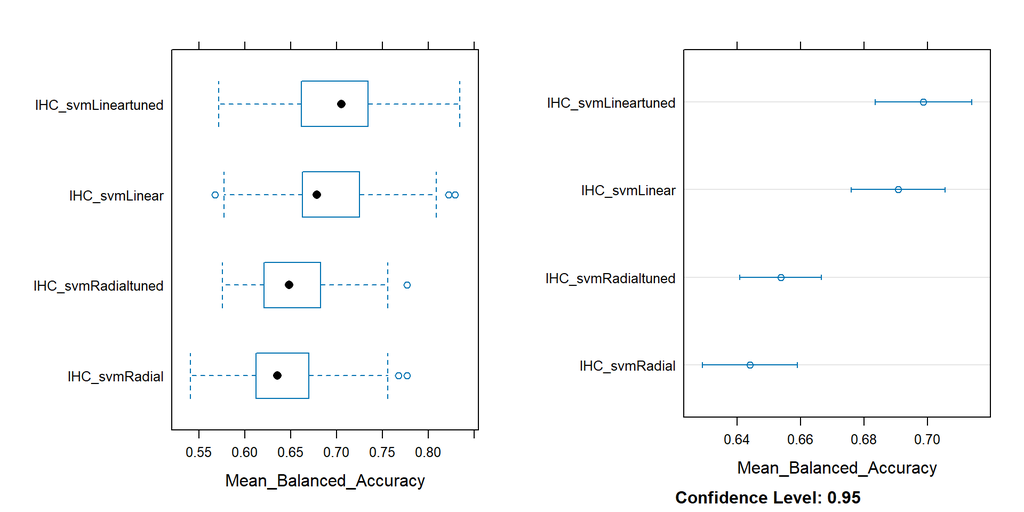

```
 Confidence intervals:
               model     lower     upper
1      IHC_svmRadial 0.6290634 0.6590298
2 IHC_svmRadialtuned 0.6408205 0.6666103
3      IHC_svmLinear 0.6760244 0.7056450
4 IHC_svmLineartuned 0.6835037 0.7140309

 Pairwise comparisons:

Call:
summary.diff.resamples(object = diff(modelresults, metric = metriccomp))

p-value adjustment: bonferroni
Upper diagonal: estimates of the difference
Lower diagonal: p-value for H0: difference = 0

Mean_Balanced_Accuracy
                   IHC_svmLinear IHC_svmLineartuned IHC_svmRadial
IHC_svmLinear                    -0.007933           0.046788
IHC_svmLineartuned 0.5160833                         0.054721
IHC_svmRadial      8.992e-06     1.562e-06
IHC_svmRadialtuned 0.0005706     3.868e-05          0.4848319
                   IHC_svmRadialtuned
IHC_svmLinear       0.037119
IHC_svmLineartuned  0.045052
IHC_svmRadial      -0.009669
IHC_svmRadialtuned



CLASSIFICATION: Ternary

 Best hyperparameters:

$Ternary_svmLinear
  C
1 1

$Ternary_svmLineartuned
     C
```

[output cut: 15 more lines]

```

Models: Ternary_svmLinear, Ternary_svmLineartuned, Ternary_svmRadial, Ternary_svmRadialtuned
Number of resamples: 50

Mean_Balanced_Accuracy
                            Min.   1st Qu.    Median      Mean   3rd Qu.
Ternary_svmLinear      0.9281477 0.9610067 0.9744563 0.9738527 0.9836485
Ternary_svmLineartuned 0.9360274 0.9567942 0.9805448 0.9736708 0.9832485
Ternary_svmRadial      0.8220361 0.8855011 0.9066284 0.9030480 0.9285056
Ternary_svmRadialtuned 0.8492274 0.8990022 0.9131443 0.9169839 0.9447000
                            Max. NA's
Ternary_svmLinear      1.0000000    0
Ternary_svmLineartuned 1.0000000    0
Ternary_svmRadial      0.9611466    0
Ternary_svmRadialtuned 0.9631968    0
```

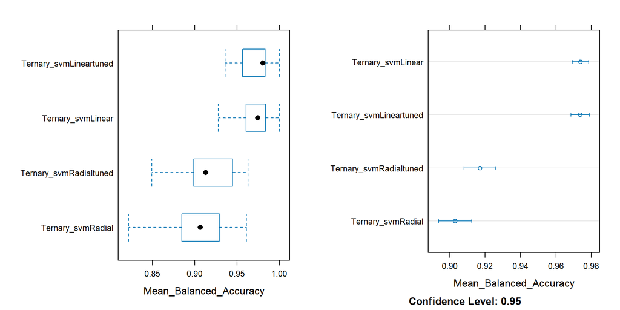

```
 Confidence intervals:
                   model     lower     upper
1      Ternary_svmRadial 0.8937288 0.9123672
2 Ternary_svmRadialtuned 0.9081368 0.9258310
3 Ternary_svmLineartuned 0.9685340 0.9788075
4      Ternary_svmLinear 0.9692719 0.9784336

 Pairwise comparisons:

Call:
summary.diff.resamples(object = diff(modelresults, metric = metriccomp))

p-value adjustment: bonferroni
Upper diagonal: estimates of the difference
Lower diagonal: p-value for H0: difference = 0

Mean_Balanced_Accuracy
                       Ternary_svmLinear Ternary_svmLineartuned
Ternary_svmLinear                         0.000182
Ternary_svmLineartuned 1
Ternary_svmRadial      < 2.2e-16         < 2.2e-16
Ternary_svmRadialtuned 1.155e-15         3.834e-15
                       Ternary_svmRadial Ternary_svmRadialtuned
Ternary_svmLinear       0.070805          0.056869
Ternary_svmLineartuned  0.070623          0.056687
Ternary_svmRadial                        -0.013936
Ternary_svmRadialtuned 4.202e-05



CLASSIFICATION: Binary

 Best hyperparameters:

$Binary_svmLinear
  C
1 1

$Binary_svmLineartuned
    C
```

[output cut: 15 more lines]

```

Models: Binary_svmLinear, Binary_svmLineartuned, Binary_svmRadial, Binary_svmRadialtuned
Number of resamples: 50

Balanced_Accuracy
                           Min.   1st Qu.    Median      Mean   3rd Qu. Max.
Binary_svmLinear      0.9151404 0.9591346 1.0000000 0.9787342 1.0000000    1
Binary_svmLineartuned 0.9087302 0.9615385 1.0000000 0.9795060 1.0000000    1
Binary_svmRadial      0.8669355 0.8944597 0.9159035 0.9278016 0.9571185    1
Binary_svmRadialtuned 0.8669355 0.9166667 0.9536020 0.9475671 0.9919355    1
                      NA's
Binary_svmLinear         0
Binary_svmLineartuned    0
Binary_svmRadial         0
Binary_svmRadialtuned    0
```

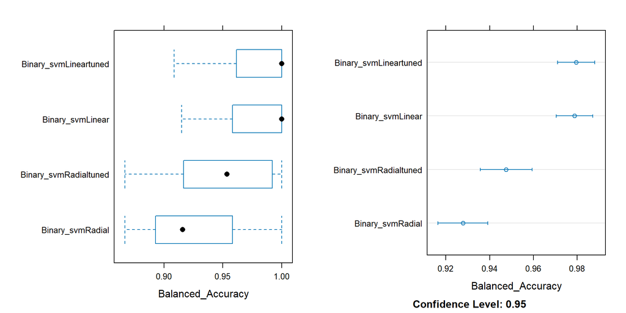

```
 Confidence intervals:
                  model     lower     upper
1      Binary_svmRadial 0.9164331 0.9391701
2 Binary_svmRadialtuned 0.9357051 0.9594290
3      Binary_svmLinear 0.9703826 0.9870858
4 Binary_svmLineartuned 0.9710726 0.9879393

 Pairwise comparisons:

Call:
summary.diff.resamples(object = diff(modelresults, metric = metriccomp))

p-value adjustment: bonferroni
Upper diagonal: estimates of the difference
Lower diagonal: p-value for H0: difference = 0

Balanced_Accuracy
                      Binary_svmLinear Binary_svmLineartuned Binary_svmRadial
Binary_svmLinear                       -0.0007718             0.0509326
Binary_svmLineartuned 1                                       0.0517044
Binary_svmRadial      1.958e-12        3.476e-12
Binary_svmRadialtuned 2.850e-05        1.416e-05             1.499e-05
                      Binary_svmRadialtuned
Binary_svmLinear       0.0311671
Binary_svmLineartuned  0.0319389
Binary_svmRadial      -0.0197654
Binary_svmRadialtuned
```

```r
# RF models
compMLmodels(rfmodels)
```

```
CLASSIFICATION: IHC

 Best hyperparameters:

$IHC_rf
  mtry
3    9

$IHC_rftuned
  mtry
4   10


 Mean_Balanced_Accuracy

Call:
summary.resamples(object = modelresults, metric = metriccomp)

Models: IHC_rf, IHC_rftuned
Number of resamples: 50

Mean_Balanced_Accuracy
                 Min.   1st Qu.    Median      Mean   3rd Qu.      Max. NA's
IHC_rf      0.6037350 0.6560208 0.6710149 0.6723694 0.6887215 0.7678314    0
IHC_rftuned 0.5892005 0.6519172 0.6702266 0.6724982 0.6932727 0.7635868    0
```

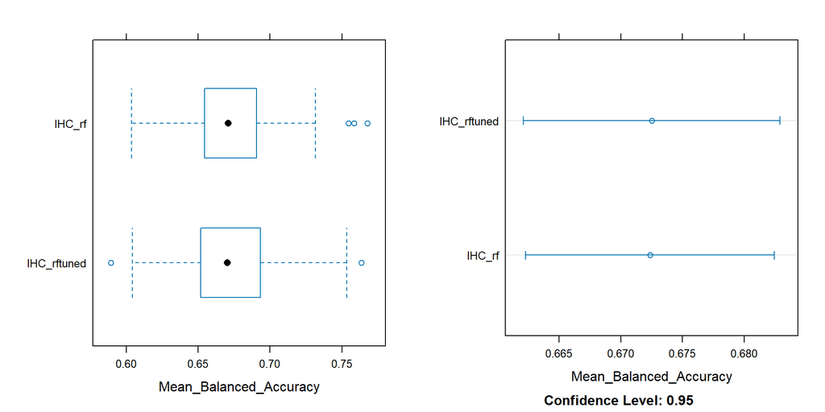

```
 Confidence intervals:
        model     lower     upper
1      IHC_rf 0.6622827 0.6824561
2 IHC_rftuned 0.6620772 0.6829193

 Pairwise comparisons:

Call:
summary.diff.resamples(object = diff(modelresults, metric = metriccomp))

p-value adjustment: bonferroni
Upper diagonal: estimates of the difference
Lower diagonal: p-value for H0: difference = 0

Mean_Balanced_Accuracy
            IHC_rf IHC_rftuned
IHC_rf             -0.0001289
IHC_rftuned 0.9662



CLASSIFICATION: Ternary

 Best hyperparameters:

$Ternary_rf
  mtry
5   16

$Ternary_rftuned
  mtry
3   16


 Mean_Balanced_Accuracy

Call:
summary.resamples(object = modelresults, metric = metriccomp)

Models: Ternary_rf, Ternary_rftuned
Number of resamples: 50

Mean_Balanced_Accuracy
                     Min.   1st Qu. Median      Mean 3rd Qu. Max. NA's
Ternary_rf      0.9547758 0.9938682      1 0.9959512       1    1    0
Ternary_rftuned 0.9547758 0.9938682      1 0.9959512       1    1    0
```

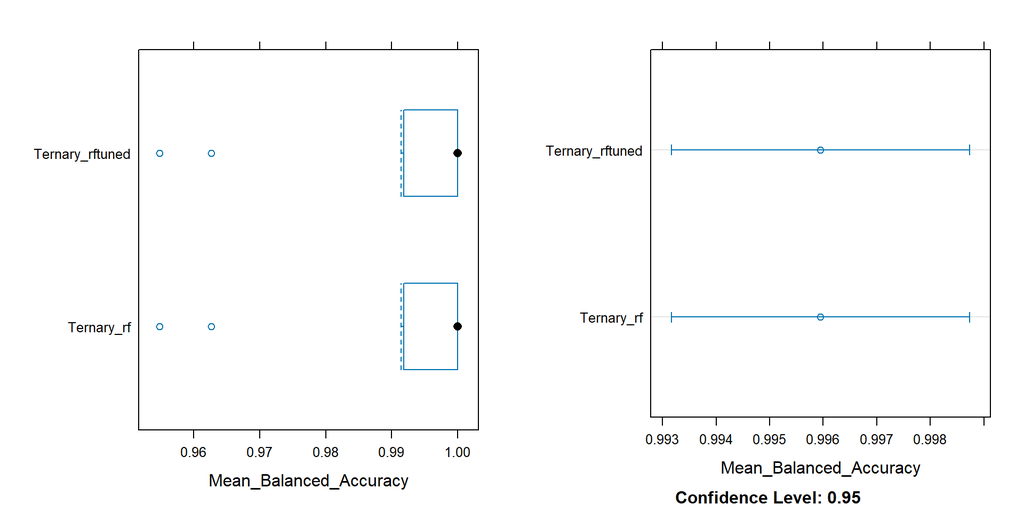

```
 Confidence intervals:
            model     lower     upper
1      Ternary_rf 0.9931672 0.9987351
2 Ternary_rftuned 0.9931672 0.9987351

 Pairwise comparisons:

Call:
summary.diff.resamples(object = diff(modelresults, metric = metriccomp))

p-value adjustment: bonferroni
Upper diagonal: estimates of the difference
Lower diagonal: p-value for H0: difference = 0

Mean_Balanced_Accuracy
                Ternary_rf Ternary_rftuned
Ternary_rf                  0
Ternary_rftuned NA



CLASSIFICATION: Binary

 Best hyperparameters:

$Binary_rf
  mtry
5   16

$Binary_rftuned
  mtry
1   14


 Balanced_Accuracy

Call:
summary.resamples(object = modelresults, metric = metriccomp)

Models: Binary_rf, Binary_rftuned
Number of resamples: 50

Balanced_Accuracy
               Min. 1st Qu. Median Mean 3rd Qu. Max. NA's
Binary_rf         1       1      1    1       1    1    0
Binary_rftuned    1       1      1    1       1    1    0
```

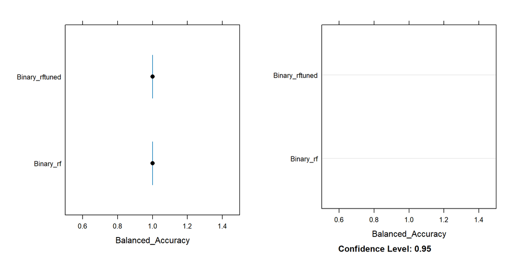

```
 Confidence intervals:
           model lower upper
1      Binary_rf    NA    NA
2 Binary_rftuned    NA    NA

 Pairwise comparisons:

Call:
summary.diff.resamples(object = diff(modelresults, metric = metriccomp))

p-value adjustment: bonferroni
Upper diagonal: estimates of the difference
Lower diagonal: p-value for H0: difference = 0

Balanced_Accuracy
               Binary_rf Binary_rftuned
Binary_rf                 0
Binary_rftuned NA
```

```r
# XGBoost models
compMLmodels(xgboostmodels)
```

```
CLASSIFICATION: IHC

 Best hyperparameters:

$IHC_xgboosttuned
  nrounds max_depth eta gamma colsample_bytree min_child_weight subsample
7     100         4 0.2     1              0.6                3       0.6

$IHC_xgboosttuned2
   nrounds max_depth eta gamma colsample_bytree min_child_weight subsample
18     100         4 0.1     1              0.6                3       0.6


 Mean_Balanced_Accuracy

Call:
summary.resamples(object = modelresults, metric = metriccomp)

Models: IHC_xgboosttuned, IHC_xgboosttuned2
Number of resamples: 50

Mean_Balanced_Accuracy
                       Min.   1st Qu.    Median      Mean   3rd Qu.      Max.
IHC_xgboosttuned  0.5914054 0.6578954 0.6718828 0.6765289 0.6899446 0.8000213
IHC_xgboosttuned2 0.6112250 0.6542187 0.6673944 0.6751369 0.6943784 0.7451958
                  NA's
IHC_xgboosttuned     0
IHC_xgboosttuned2    0
```

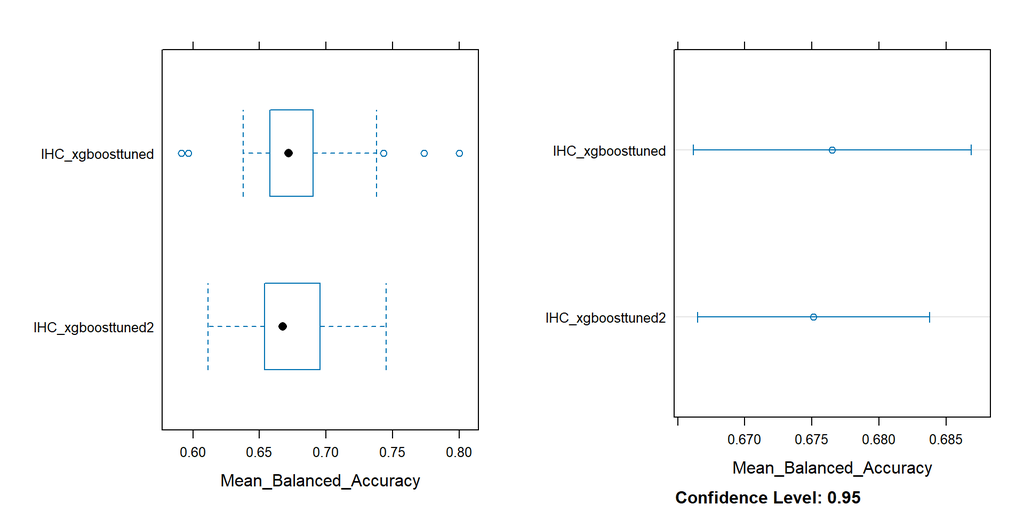

```
 Confidence intervals:
              model     lower     upper
1 IHC_xgboosttuned2 0.6664852 0.6837885
2  IHC_xgboosttuned 0.6661765 0.6868814

 Pairwise comparisons:

Call:
summary.diff.resamples(object = diff(modelresults, metric = metriccomp))

p-value adjustment: bonferroni
Upper diagonal: estimates of the difference
Lower diagonal: p-value for H0: difference = 0

Mean_Balanced_Accuracy
                  IHC_xgboosttuned IHC_xgboosttuned2
IHC_xgboosttuned                   0.001392
IHC_xgboosttuned2 0.6814



CLASSIFICATION: Ternary

 Best hyperparameters:

$Ternary_xgboosttuned
  nrounds max_depth   eta gamma colsample_bytree min_child_weight subsample
1      50         1 0.001     0              0.6                1         1

$Ternary_xgboosttuned2
  nrounds max_depth   eta gamma colsample_bytree min_child_weight subsample
1      50         1 0.001     0              0.6                1         1


 Mean_Balanced_Accuracy

Call:
summary.resamples(object = modelresults, metric = metriccomp)

Models: Ternary_xgboosttuned, Ternary_xgboosttuned2
Number of resamples: 50

Mean_Balanced_Accuracy
                           Min.   1st Qu. Median      Mean 3rd Qu. Max. NA's
Ternary_xgboosttuned  0.9547758 0.9938682      1 0.9959512       1    1    0
Ternary_xgboosttuned2 0.9547758 0.9938682      1 0.9959512       1    1    0
```

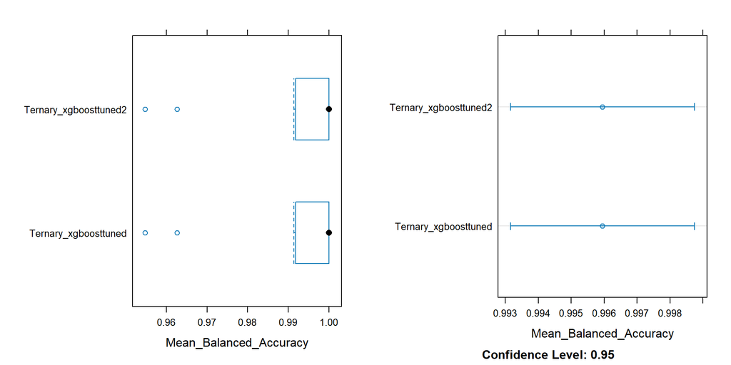

```
 Confidence intervals:
                  model     lower     upper
1  Ternary_xgboosttuned 0.9931672 0.9987351
2 Ternary_xgboosttuned2 0.9931672 0.9987351

 Pairwise comparisons:

Call:
summary.diff.resamples(object = diff(modelresults, metric = metriccomp))

p-value adjustment: bonferroni
Upper diagonal: estimates of the difference
Lower diagonal: p-value for H0: difference = 0

Mean_Balanced_Accuracy
                      Ternary_xgboosttuned Ternary_xgboosttuned2
Ternary_xgboosttuned                        0
Ternary_xgboosttuned2 NA



CLASSIFICATION: Binary

 Best hyperparameters:

$Binary_xgboosttuned
  nrounds max_depth   eta gamma colsample_bytree min_child_weight subsample
1      50         1 0.001     0              0.6                1       0.6

$Binary_xgboosttuned2
  nrounds max_depth   eta gamma colsample_bytree min_child_weight subsample
1      50         1 0.001     0              0.6                1       0.6


 Balanced_Accuracy

Call:
summary.resamples(object = modelresults, metric = metriccomp)

Models: Binary_xgboosttuned, Binary_xgboosttuned2
Number of resamples: 50

Balanced_Accuracy
                     Min. 1st Qu. Median Mean 3rd Qu. Max. NA's
Binary_xgboosttuned     1       1      1    1       1    1    0
Binary_xgboosttuned2    1       1      1    1       1    1    0
```

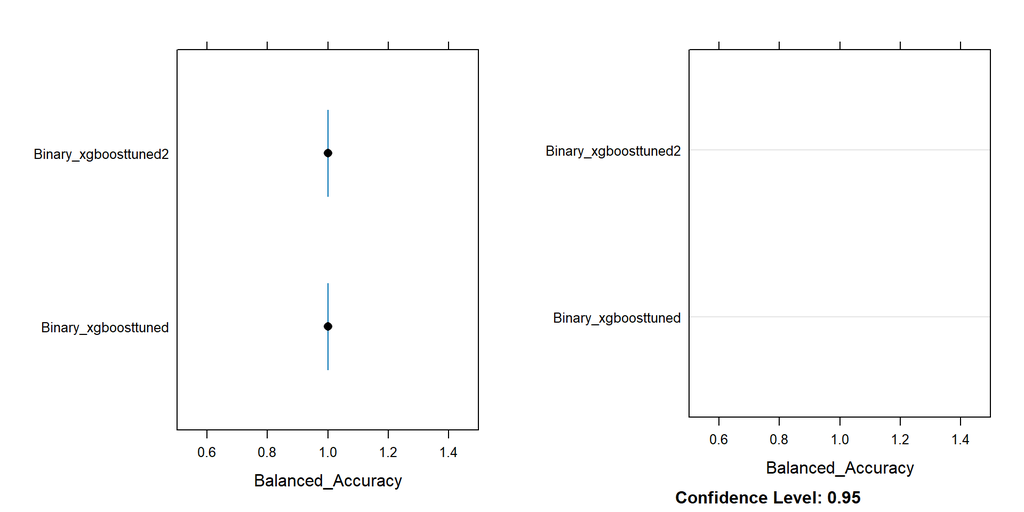

```
 Confidence intervals:
                 model lower upper
1  Binary_xgboosttuned    NA    NA
2 Binary_xgboosttuned2    NA    NA

 Pairwise comparisons:

Call:
summary.diff.resamples(object = diff(modelresults, metric = metriccomp))

p-value adjustment: bonferroni
Upper diagonal: estimates of the difference
Lower diagonal: p-value for H0: difference = 0

Balanced_Accuracy
                     Binary_xgboosttuned Binary_xgboosttuned2
Binary_xgboosttuned                       0
Binary_xgboosttuned2 NA
```

The best performing SVM models are: IHC_svmLineartuned (highest median, mean and CI, although no significantly different from base linear), Ternary_svmLineartuned (highest median, mean and CI almost identical to those of base linear, although no significantly different from base linear), and Binary_svmLineartuned (highest median, mean and CI, although no significantly different from base linear).

The best performing RF models are: IHC_rf (highest median, mean and CI almost identical to those of the tuned one, although no significantly different from the tuned one), Ternary_rf (exact same than the tuned one so we can keep the default), and Binary_rf (not the exact same than the tuned one but similar results regarding balanced accuracy so we keep the default).

The best performing XGBoost models are: IHC_xgboosttuned (highest median, mean and CI, although no significantly different from the re-tuned one), Ternary_xgboosttuned (exact same than the re-tuned one so we keep the simplest), and Binary_xgboosttuned (exact same than the re-tuned one so we keep the simplest).

Now that the best performing (best tuned) models have been sorted out we can create a unique list with those models (CV results) and save it:

```r
## New list with the kept models only SVM models
modelsML <- svmmodels[c("IHC_svmLineartuned", "Ternary_svmLineartuned", "Binary_svmLineartuned")]
# RF models
modelsML <- append(modelsML, rfmodels[c("IHC_rf", "Ternary_rf", "Binary_rf")])
# XGBOOST models
modelsML <- append(modelsML, xgboostmodels[c("IHC_xgboosttuned", "Ternary_xgboosttuned",
    "Binary_xgboosttuned")])

# Saving this list save(modelsML, file = 'modelsML.rda')
```

### APPLICATION OF THE SELECTED ML MODELS TO THE TEST DATASET

It is time to use the model on the test set. To do that, we first retrain the selected models on the full training set without using CV nor oversampling since at this step the models are meant to be representative of the original data, with the true frequencies of the classes, etc. Then, such retrained models are applied to the test set to obtain the test results. A list is generated. This list, for each selected model, compiles the retrained model and the test results and associated ROC curves. We also print the full results in distinct files as we did previously when training models with CV.

We first set the new parameters for *trainControl()*:

```r
# Setting of the parameters for final evaluation (on test set)
controltrain <- trainControl(method = "none", classProbs = T, summaryFunction = multiClassSummary,
    savePredictions = "final")
```

Now we compute the results. As mentionned before, these are also saved into separate text files (the specific name of each file is iteratively created and specified after the argument ‘outfile=’ when using the *mlmodel()* function):

```r
# Generating test results
evaluationML <- lapply(names(modelsML), function(model) {

    # Choosing the correct model type
    modeltype <- case_when(grepl("_svmLinear", model) ~ "svmLinear", grepl("_rf",
        model) ~ "rf", grepl("_xgboost", model) ~ "xgbTree", TRUE ~ NA_character_)

    # Choosing the correct classification along with the predictors
    if (grepl("IHC", model)) {
        training <- datatrain[-c(22, 23)]
    } else if (grepl("Ternary", model)) {
        training <- datatrain[-c(21, 23)]
    } else if (grepl("Binary", model)) {
        training <- datatrain[-c(21, 22)]
    }

    # Applying the function *mlmodel()*
    mlmodel(train = training, test = testdata, model = modeltype, tunegrid = modelsML[[model]]$cvmodel$bestTune,
        outfile = paste0("test_res_", model, ".txt"))

})
names(evaluationML) <- names(modelsML)  # Giving the test results in the list the names corresponding to their respective training model
```

We finally save the list:

#save(evaluationML, file = “evaluationML.rda”)

### CV RESULTS, TEST RESULTS, AND ROC CURVE PLOTS

The CV and test results (confusion matrices and statistics, as well as macro-metrics) can be found in the *ML_models_results_CV&test.xlsx* document. In general, the results are extremely similar between the CV results and test results and vary the most for SVM, in particular in the case of the traditional IHC classification. RF and XGBoost perform very similarly. In general, the models perform the worst for the traditional IHC classification (e.g., Kappa ~0.35–0.52, Balanced Accuracy ~0.65–0.70, AUC ~0.74–0.78), while the performances are very high (and even maximal) and highly similar in the two alternative classifications (e.g., Kappa ~0.88–1, Balanced Accuracy ~0.93–1, AUC ~0.99–1, the values being most generally close to 1).

If we had to order these models by overall performance the order would be the following (for each classification):

IHC_RF ≈ IHC_XGBoost < IHC_SVM.

Ternary_SVM < Ternary_RF = Ternary_XGBoost (the former very slightly better for AUC).

Binary~SVM < Binary_RF = Binary_XGBoost.

In definitive, the traditional IHC classification seems the least “reliable” while the alternative binary one is perhaps the most but not significantly more than the alternative ternary one.

Let’s now take a look at the ROC curves. We can directly load the two lists previously created, containing the CV results and test results, respectively:

```r
# Loading the list with the selected ML model CV results as well as the list
# with the test results
load(file = "modelsML.rda")
load(file = "evaluationML.rda")
```

We create plots showing both the CV ROC curves and test ROC curves in single panels:

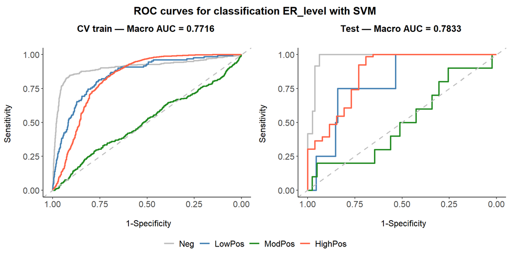

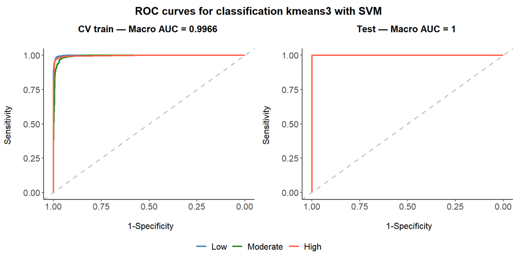

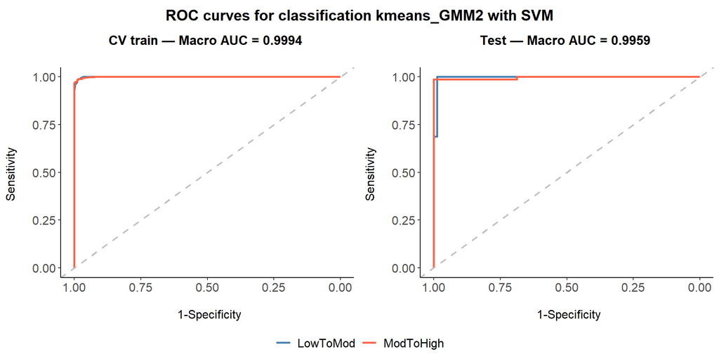

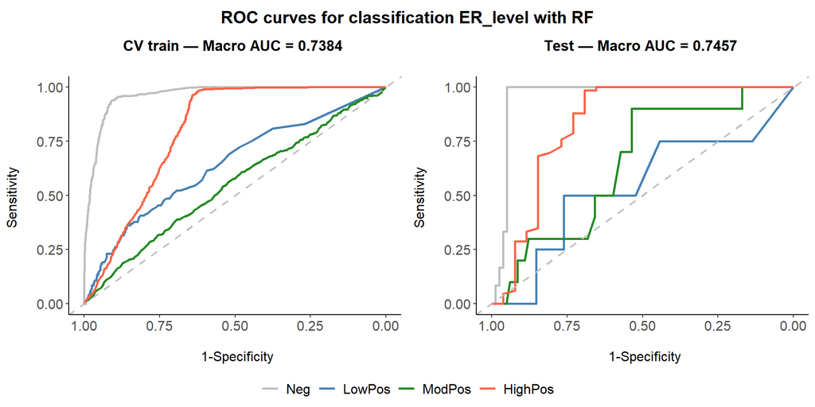

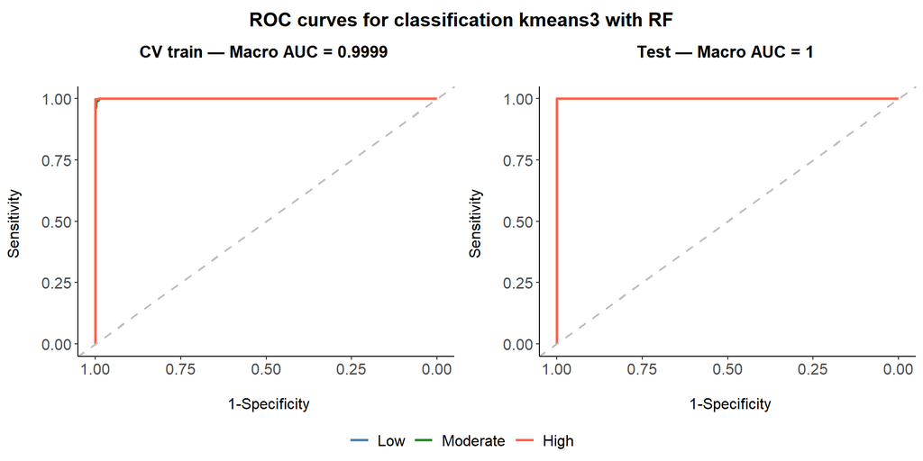

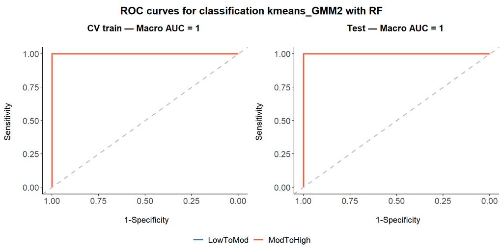

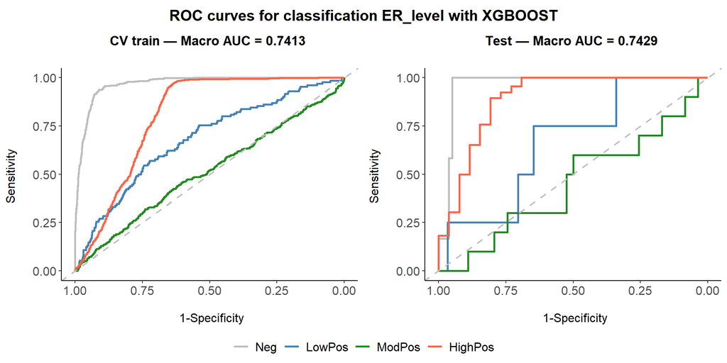

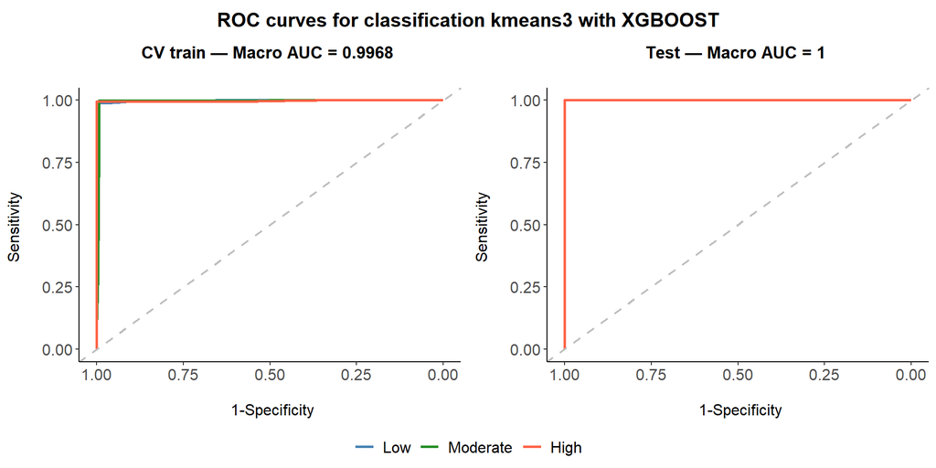

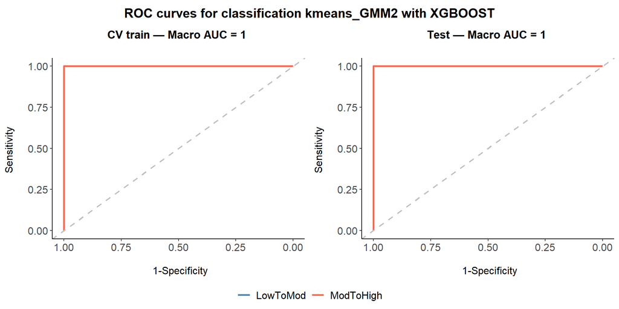

```r
## Loop for generating double plots of CV training ROC curves and test ROC
## curves from the two previous lists

for (model in names(modelsML)) {

    # Choosing the correct model type
    modeltype <- case_when(grepl("_svmLinear", model) ~ "SVM", grepl("_rf", model) ~
        "RF", grepl("_xgboost", model) ~ "XGBOOST", TRUE ~ NA_character_)

    # Choosing the correct classification
    if (grepl("IHC", model)) {
        classif <- colnames(datatrain)[21]
    } else if (grepl("Ternary", model)) {
        classif <- colnames(datatrain)[22]
    } else if (grepl("Binary", model)) {
        classif <- colnames(datatrain)[23]
    }

    # Extracting the two ROC plots
    p1 <- modelsML[[model]]$cvrocplot
    p2 <- evaluationML[[model]]$testrocplot

    # Extracting the two (macro) AUC values from the two original plot titles
    aucp1 <- sub(".*(Macro.*)", "\\1", p1$labels$title)
    aucp2 <- sub(".*(Macro.*)", "\\1", p2$labels$title)

    legend <- get_legend(p1 + theme(legend.position = "bottom"))  # Common legend for the final figure

    # Modifying the individual plots
    p1 <- p1 + labs(title = paste("CV train —", aucp1, "\n")) + theme(legend.position = "none")
    p2 <- p2 + labs(title = paste("Test —", aucp2, "\n")) + theme(legend.position = "none")

    # Grid with all the plots
    grid <- plot_grid(plotlist = list(p1, p2), ncol = 2)
    # Common title
    title <- ggdraw() + draw_label(paste0("ROC curves for classification ", classif,
        " with ", modeltype), fontface = "bold", size = 15)
    # Final figure
    fig <- plot_grid(title, grid, ncol = 1, nrow = 2, rel_heights = c(0.1, 1))
    print(plot_grid(fig, legend, ncol = 1, nrow = 2, rel_heights = c(1, 0.1)))
}
```

### SHAP VALUES COMPUTATION AND ASSOCIATED PLOTS

Based on the retrained ML models, i.e., the models that were retained on the full training set, we can now compute SHAP values and producing a feature importance plot for each class of each classification. The custom function *plotshap()* was developed for that purpose. It computes and returns the matrices of mean SHAP values (both raw and absolute), the per-class plots, and a plot grid with all plots together. Because computing SHAP values can take long and is not straightforward when it comes to SVM models, we use the SHAP approximation framework of the **fastshap** package, through the function *explain()*. To have more accurate results, we use 500 Monte-Carlo simulations and the option for adjusting the SHAP values, which adjusts the sum of the estimated SHAP values to satisfy the local accuracy property.

This function is applied to each type of model and classification, separately, and the resulting objects can be saved once again in a unique list:

```r
# For the SVM models
IHC_SVM_SHAP <- plotshap(evaluationML[1], shap = T)
Ternary_SVM_SHAP <- plotshap(evaluationML[2], shap = T)
Binary_SVM_SHAP <- plotshap(evaluationML[3], shap = T)

# For the RF models
IHC_RF_SHAP <- plotshap(evaluationML[4], shap = T)
Ternary_RF_SHAP <- plotshap(evaluationML[5], shap = T)
Binary_RF_SHAP <- plotshap(evaluationML[6], shap = T)

# For the XGBoost models
IHC_XGBoost_SHAP <- plotshap(evaluationML[7], shap = T)
Ternary_XGBoost_SHAP <- plotshap(evaluationML[8], shap = T)
Binary_XGBoost_SHAP <- plotshap(evaluationML[9], shap = T)


# List will all SHAP results
fullplotshap <- list(IHC_SVM_SHAP = IHC_SVM_SHAP, Ternary_SVM_SHAP = Ternary_SVM_SHAP,
    Binary_SVM_SHAP = Binary_SVM_SHAP, IHC_RF_SHAP = IHC_RF_SHAP, Ternary_RF_SHAP = Ternary_RF_SHAP,
    Binary_RF_SHAP = Binary_RF_SHAP, IHC_XGBoost_SHAP = IHC_XGBoost_SHAP, Ternary_XGBoost_SHAP = Ternary_XGBoost_SHAP,
    Binary_XGBoost_SHAP = Binary_XGBoost_SHAP)

# Saving these objects in a unique list save(fullplotshap,
# file='fullplotshap.rda')
```

Now we can directly load this list and show the nine final plot grids:

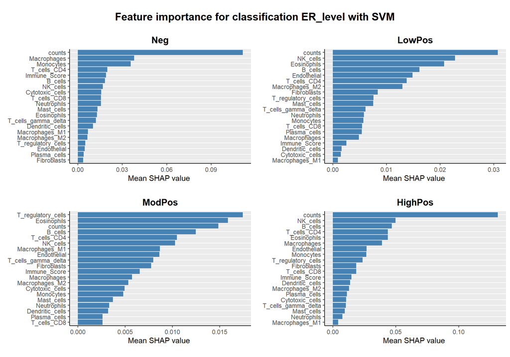

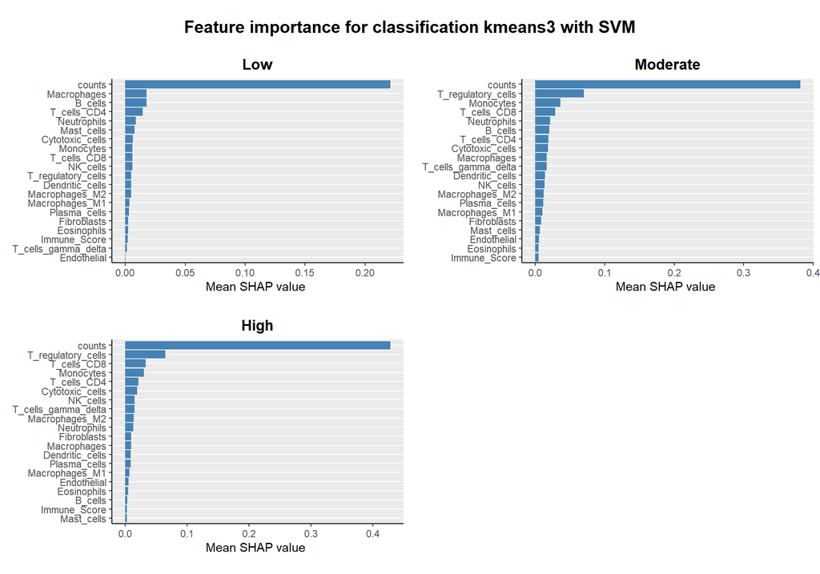

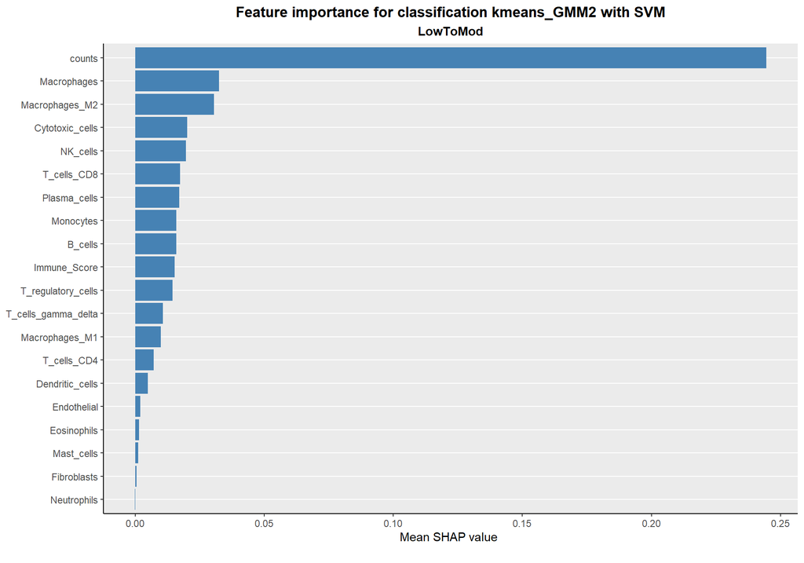

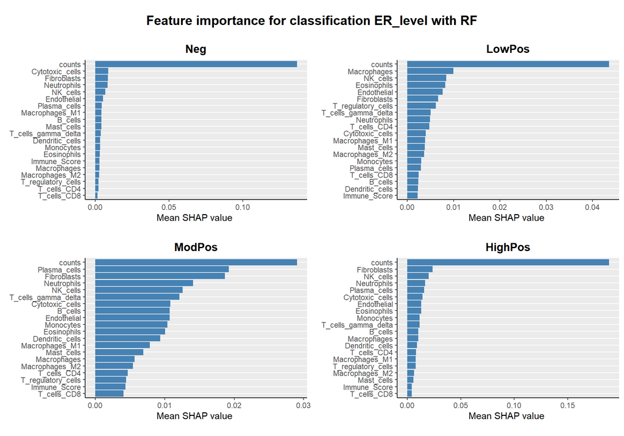

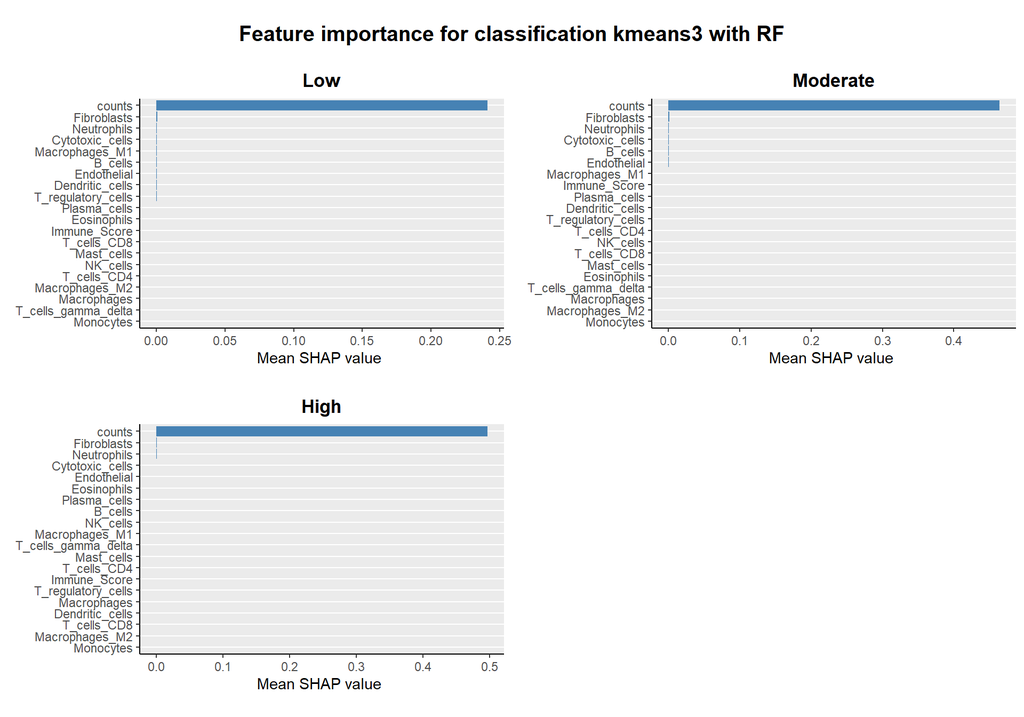

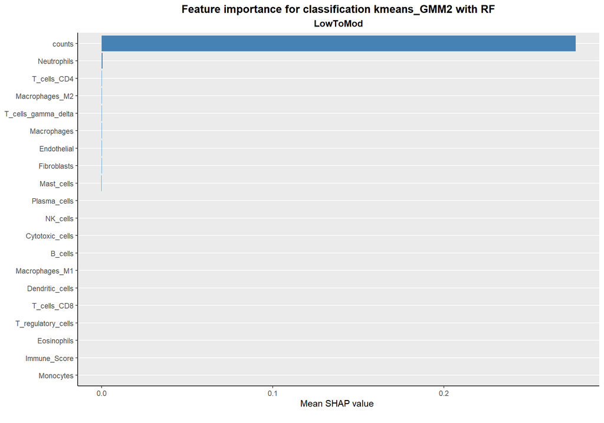

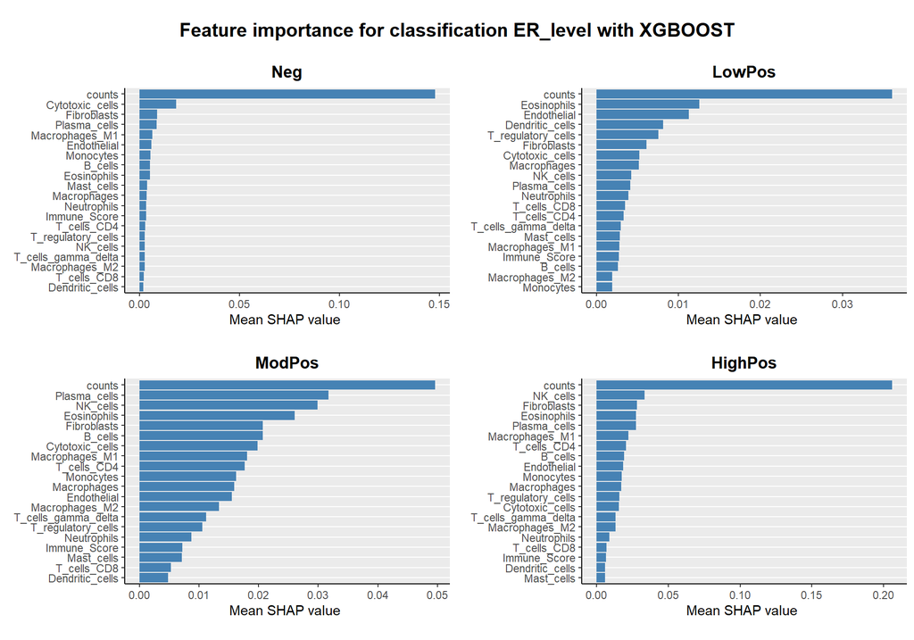

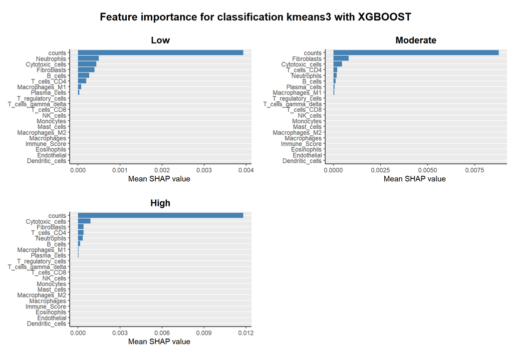

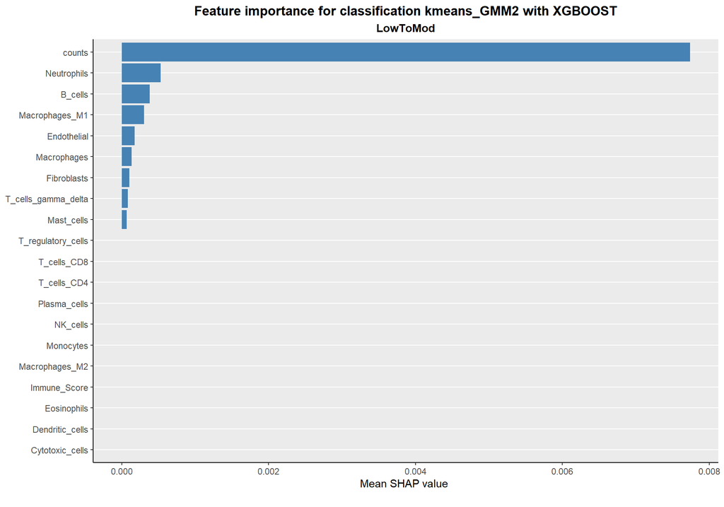

```r
# Loading the list of feature importance plots
load(file = "fullplotshap.rda")

# Showing the plots
for (model in fullplotshap) {
    print(model$final_plot)
}
```

First of all, we observe that ESR1 expression (“counts”) is always the most important feature and shows a relatively much higher mean SHAP value than the other features. This is especially true for the alternative classifications and when the algorithm employed is RF or XGBoost (most marked for RF). The only exception is for the “10-50%” category (“ModPos” here) of the traditional IHC classification for which ESR1 expression is the third most important feature (but its SHAP value is not very different than those of the two most important features).

Now we can check what are the most important features across all classes, averaging the per-class SHAP values for each model type, for each classification. Plots of the 10 most influent (important) features can be produced as well:

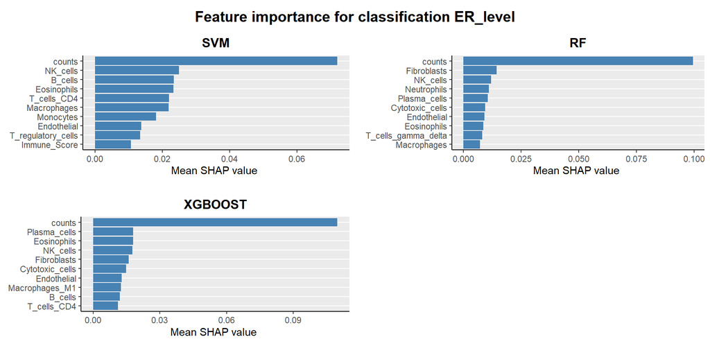

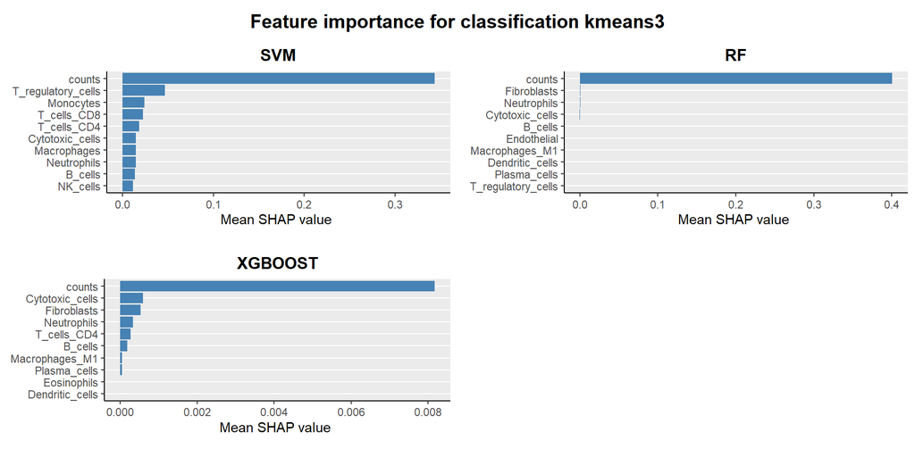

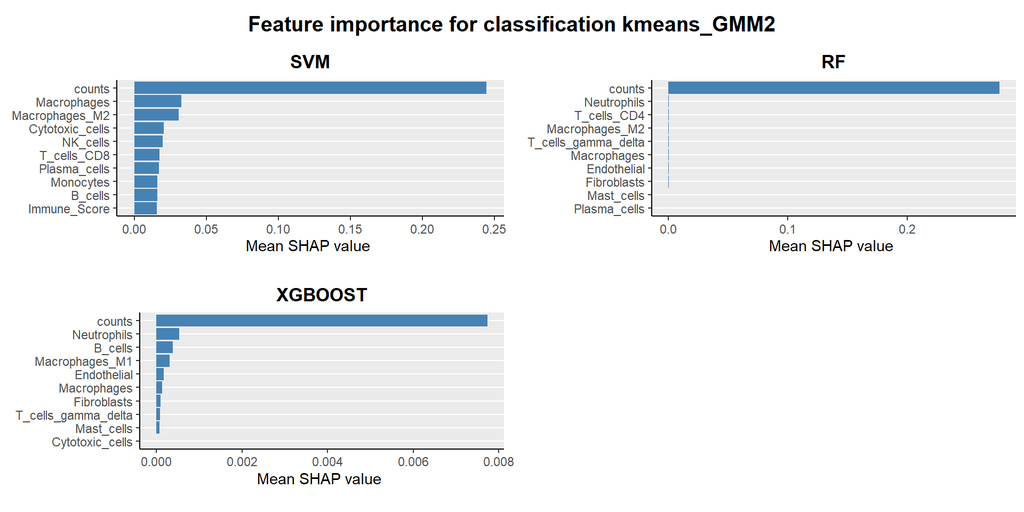

```r
## List containing, for each classification and each model type, the mean
## absolute SHAP values averaged across all classes
avgclassshap <- lapply(c("IHC", "Ternary", "Binary"), function(classif) {
    # Creating an internal list with the models corresponding to one
    # classification only
    listmodels <- fullplotshap[grep(classif, names(fullplotshap))]
    # Calculating the averages across all classes
    listclassavg <- lapply(listmodels, function(model) {
        rowMeans(model$magn_shap_values)
    })
})
names(avgclassshap) <- c("IHC", "Ternary", "Binary")


## Plots of the 10 most important features for each model type for each
## classification List of plots
for (classif in names(avgclassshap)) {

    # Choosing the correct classification
    if (grepl("IHC", classif)) {
        nameclassif <- colnames(datatrain)[21]
    } else if (grepl("Ternary", classif)) {
        nameclassif <- colnames(datatrain)[22]
    } else if (grepl("Binary", classif)) {
        nameclassif <- colnames(datatrain)[23]
    }

    # List of plots (one for each model type)
    plotlist <- lapply(names(avgclassshap[[classif]]), function(model) {

        # Choosing the correct type of model
        modeltype <- case_when(grepl("SVM", model) ~ "SVM", grepl("RF", model) ~
            "RF", grepl("XGBoost", model) ~ "XGBOOST", TRUE ~ NA_character_)

        df <- data.frame(immunvar = names(avgclassshap[[classif]][[model]]), shap = avgclassshap[[classif]][[model]],
            row.names = NULL)
        df <- df[order(df$shap, decreasing = T), ]  # Important to reorder the values from most to least important so that the 10 first can then be selected

        ggplot(df[1:10, ], aes(x = shap, y = reorder(immunvar, shap))) + geom_col(fill = "steelblue") +
            labs(x = "Mean SHAP value \n", y = NULL, title = modeltype) + theme_gray() +
            theme(panel.grid.major.x = element_blank(), panel.grid.minor = element_blank(),
                axis.line = element_line(color = "black"), plot.title = element_text(face = "bold",
                  hjust = 0.5))
    })
    names(plotlist) <- names(classif)

    # Grid with all the plots
    grid <- plot_grid(plotlist = plotlist, ncol = 2)
    # Common title
    title <- ggdraw() + draw_label(paste("Feature importance for classification",
        nameclassif), fontface = "bold", size = 15)
    # Final figure
    print(plot_grid(title, grid, ncol = 1, nrow = 2, rel_heights = c(0.1, 1)))
}
```

We can also check what are the most important features across all model types, that-is-to-say, the most important features for each classification, averaging across model types. For that purpose we need to first normalize (using sum normalization) the class-average SHAP values of each model type within each classification, and then compute the averages across all model types (for each classification):

```r
## List containing, for each classification, the overall mean absolute SHAP
## values (averaged across all model types)
overallshap <- lapply(avgclassshap, function(classif) {
    # Applying sum normalization to the SHAP values of each model type
    listmodelavg <- lapply(classif, function(mod) {
        mod/sum(mod)
    })
    # Averaging the normalized SHAP values across all model types
    rowMeans(as.data.frame(listmodelavg))
})
names(overallshap) <- c("IHC", "Ternary", "Binary")
# Converting the list to table
(overallshap <- as.data.frame(overallshap))
```

```
                           IHC     Ternary      Binary
B_cells             0.04625559 0.013792804 0.024470685
Cytotoxic_cells     0.03719990 0.028042310 0.014026431
Dendritic_cells     0.02123207 0.005418307 0.003406590
Eosinophils         0.05474283 0.002367890 0.001110004
Macrophages         0.04348621 0.008271880 0.027605814
Mast_cells          0.02100685 0.003290640 0.003400834
NK_cells            0.06066272 0.006610987 0.013677531
Neutrophils         0.03011097 0.019444325 0.019419764
T_cells_CD4         0.04112439 0.019077009 0.005315502
T_cells_CD8         0.01977783 0.012825722 0.012119488
T_cells_gamma_delta 0.02853739 0.006189615 0.010703603
T_regulatory_cells  0.03058039 0.026286753 0.010007720
Macrophages_M1      0.02671320 0.005743644 0.017717567
Macrophages_M2      0.02418769 0.005884445 0.021506401
Endothelial         0.04032081 0.002359206 0.007832452
Fibroblasts         0.04654726 0.022160916 0.004326401
Monocytes           0.03926053 0.013678410 0.011039574
Plasma_cells        0.03969341 0.005899602 0.011882883
Immune_Score        0.02094651 0.001914222 0.010619795
counts              0.32761345 0.790741313 0.769810961
```

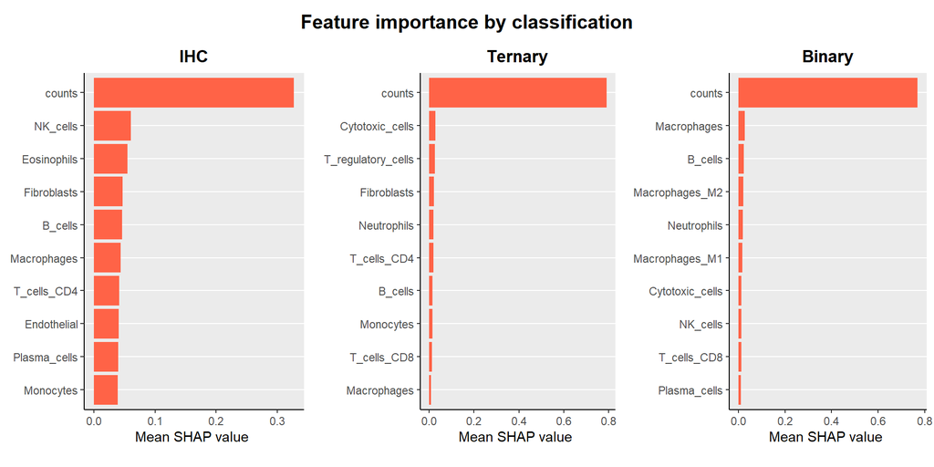

```r
## Plots of the 10 most important features for ach classification List of plots
overallshapplot <- lapply(colnames(overallshap), function(classif) {

    df <- data.frame(immunvar = rownames(overallshap), shap = overallshap[, classif],
        row.names = NULL)
    df <- df[order(df$shap, decreasing = T), ]

    ggplot(df[1:10, ], aes(x = shap, y = reorder(immunvar, shap))) + geom_col(fill = "tomato") +
        labs(x = "Mean SHAP value \n", y = NULL, title = classif) + theme_gray() +
        theme(panel.grid.major.x = element_blank(), panel.grid.minor = element_blank(),
            axis.line = element_line(color = "black"), plot.title = element_text(face = "bold",
                hjust = 0.5))
})
names(overallshapplot) <- colnames(overallshap)

# Grid with all the plots
grid <- plot_grid(plotlist = overallshapplot, ncol = 3)
# Common title
title <- ggdraw() + draw_label("Feature importance by classification", fontface = "bold",
    size = 15)
# Final figure
plot_grid(title, grid, ncol = 1, nrow = 2, rel_heights = c(0.1, 1))
```

Based on these values we can generate a heatmap correlating the three classifications and the 20 immunological features:

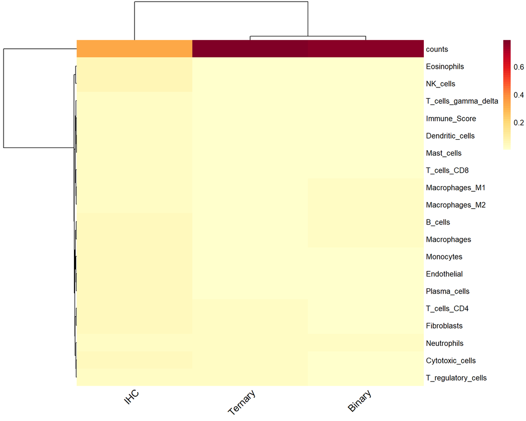

```r
# Defining a color gradient
heatcol <- colorRampPalette(RColorBrewer::brewer.pal(9, "YlOrRd"))(50)
# Heatmap
pheatmap::pheatmap(overallshap, treeheight_row = 100, border_color = NA, fontsize_col = 13,
    angle_col = 45, color = heatcol)
```